# Data

## 8. Ratings and awards

These ratings typically reflect the general appeal of the movie to the public or gather opinions from a larger body of critics. Whereas awards are given by professional societies that may evaluate a movie on specific attributes, such as artistic performance, screenplay, sound design, etc.

Study the relationship between ratings and awards using graphs (awards here refers to wins and/or nominations).

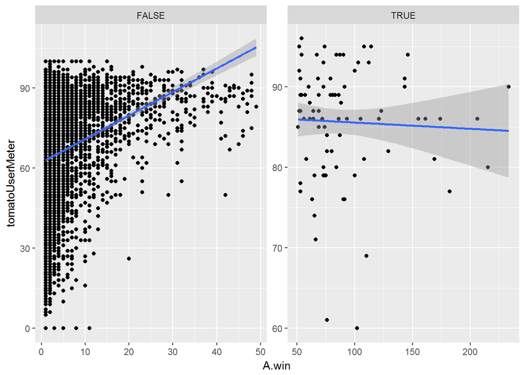

```r
# TODO: Show how ratings and awards are related
plot8.1 = ggplot(df[!is.na(df$A.win),], aes(A.win, tomatoUserMeter)) +
  geom_point() +
  facet_wrap(~(A.win>50), scales="free") +
  geom_smooth(method="lm")

plot8.2 = ggplot(df, aes(factor(!is.na(A.win)), tomatoUserMeter)) +
  geom_boxplot()

plot8.3 = ggplot(df[!is.na(df$A.nomination), ], aes(A.nomination, tomatoUserMeter)) +
  geom_point() +
  facet_wrap(~(A.nomination>100), scales="free") +
  geom_smooth(method="lm")

plot8.4 = ggplot(df, aes(factor(!is.na(A.nomination)), tomatoUserMeter)) +
  geom_boxplot()


plot8.1
```

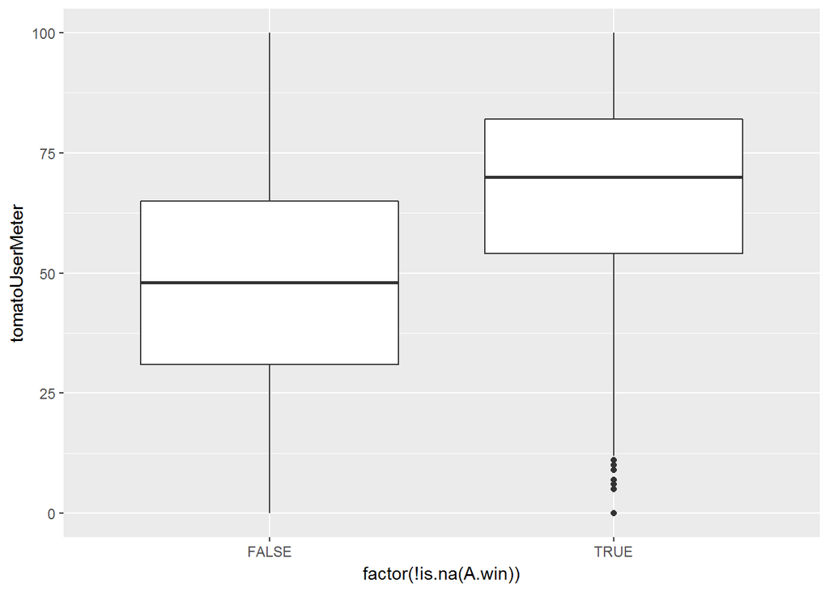

```r
plot8.2
```

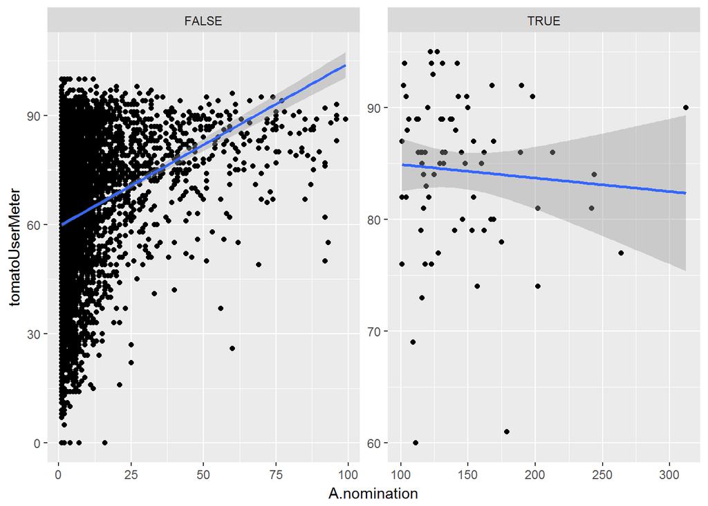

```r
plot8.3
```

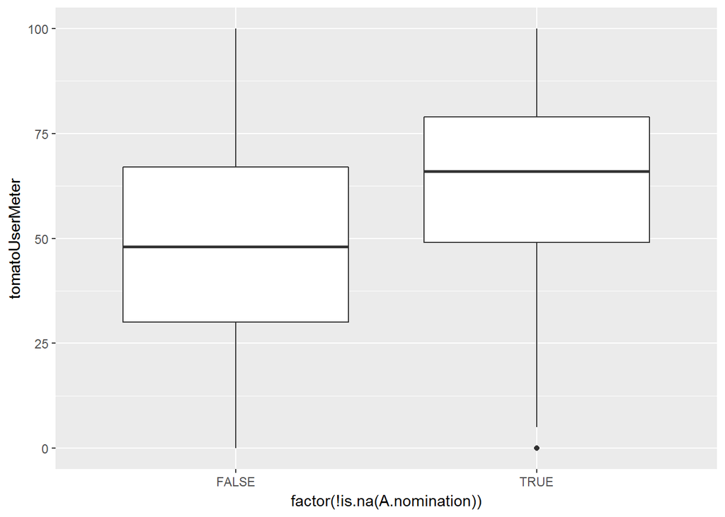

```r
plot8.4
```

**Q**: How good are these ratings in terms of predicting the success of a movie in winning awards or nominations? Is there a high correlation between two variables?

## 9. Expected insights

Come up with two new insights (backed up by data and graphs) that is expected. Here ânewâ means insights that are not an immediate consequence of one of the above tasks. You may use any of the columns already explored above or a different one in the dataset, such as `Title`, `Actors`, etc.

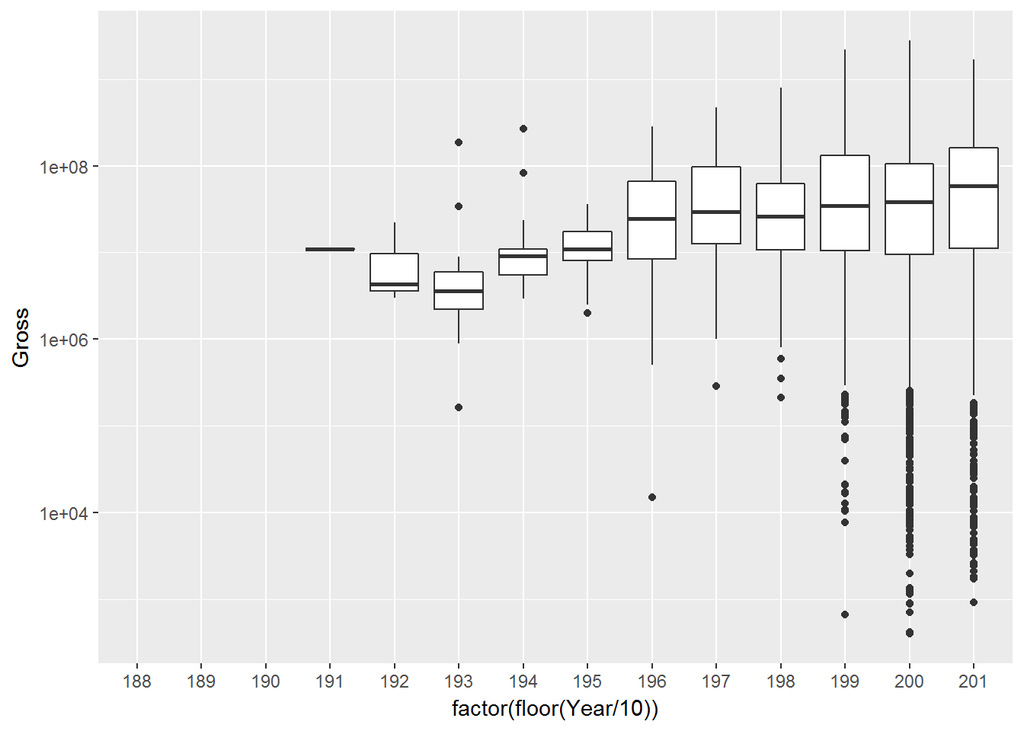

```r
# TODO: Find and illustrate two expected insights
#plot show Gross increase with years
plot9.1 = ggplot(df, aes(factor(floor(Year/10)), Gross)) +
  geom_boxplot() +
  scale_y_log10()

#plot shows movies directed by James Cameron have high Gross revenue.
plot9.2 = ggplot(df, aes(factor(Director == "James Cameron"), Gross)) +
  geom_boxplot()

plot9.1
```

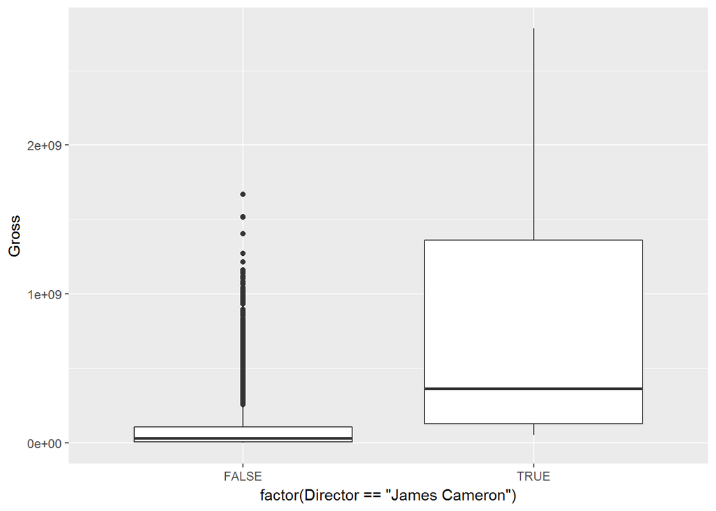

```r
plot9.2
```

**Q**: Expected insight #1.

**A**: Gross revenues increase with years. This may due to 1) the inflation, 2) movies are more popular than earlier years.

**Q**: Expected insight #2.

**A**: Movies directed by famous directors have high gross revenues. For example, the movies directed by James Cameron have very high gross revenues comapared with the rest movies.

## 10. Unexpected insight

Come up with one new insight (backed up by data and graphs) that is unexpected at first glance and do your best to motivate it. Same instructions apply as the previous task.

```r
# TODO: Find and illustrate one unexpected insight
df.new = df[!is.na(df$Gross) & !is.na(df$tomatoRotten & !is.na(df$Budget)), c(37, 24, 35)]
df.new = df.new[rev(order(df.new$tomatoRotten)),]
df.new[1:10, ]
```

```
##             Gross tomatoRotten  Budget
## 1985    868160194          249 2.5e+08
## 110978  836519699          196 2.1e+08
## 110240  304249198          187 9.2e+07
## 17662   570978470          182 4.0e+07
## 110996  365491792          180 2.0e+08
## 448      82145379          178 1.0e+08
## 110569 1045663875          175 2.5e+08
## 111417   77593167          173 3.2e+07
## 17718    91678442          173 4.2e+07
## 110751  319713881          172 1.5e+08
```

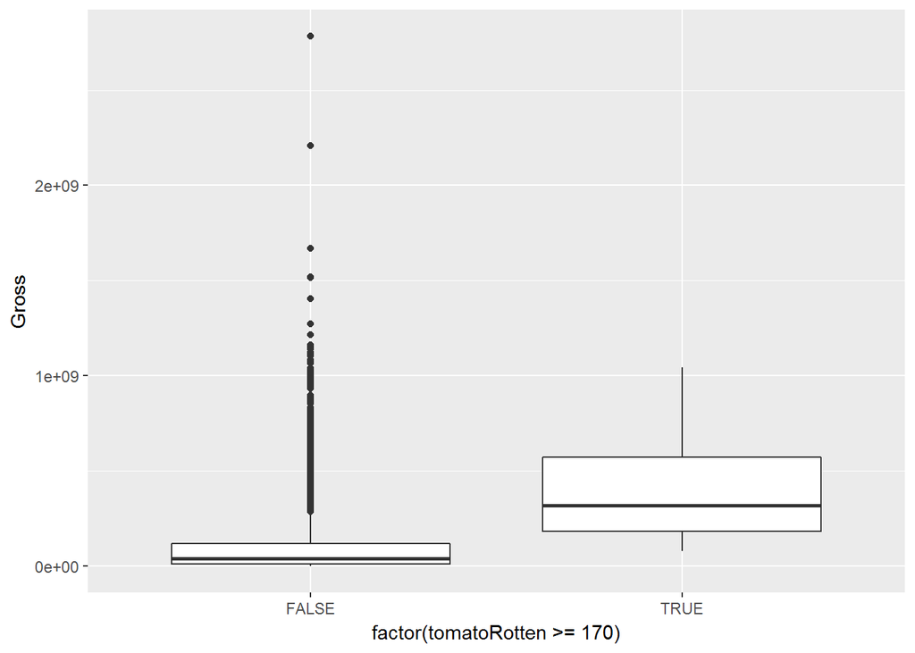

```r
plot10.1 = ggplot(df.new, aes(factor(tomatoRotten >= 170), Gross)) +
  geom_boxplot()

plot10.2 = ggplot(df.new, aes(factor(tomatoRotten >= 170), Budget)) +
  geom_boxplot()

plot10.1
```

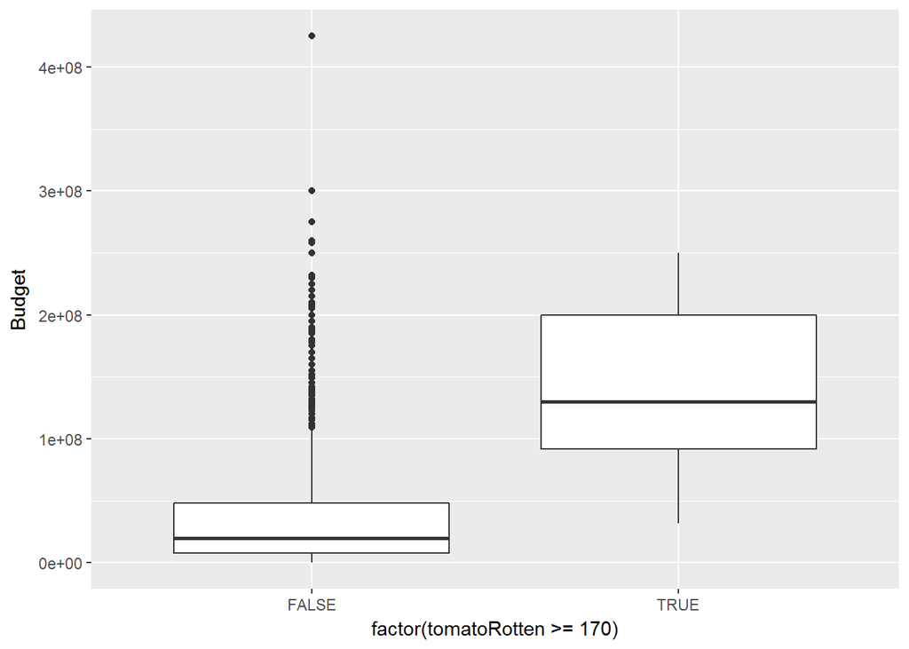

```r
plot10.2
```

**Q**: Unexpected insight.

**A**: Movies with large number of tomatoRotten are usually bad movies. Interestingly, the top 10 movies with highest tomatoRotten number have much higher gross revenues comapred the rest movies. Possible explanation is that these are popular and high budget movies, thus have so many bad reviews. The explanation is supported by the boxplot of budgets, that these ten movies have much higher budgets compared with average movies.